# Аварский диктант

Г. Мороз

2020-01-08

- Фамилия
- Имя
- Возраст (заполнен 185 раз, 47%)
- Город (МХК 81% vs СПб 19%)
- Пол (Ж 52%, М 48%)
- Количество ошибок
- Оценка

Визуализируем все наши переменные (возьмем подгруппу людей, которые указали свой возраст)

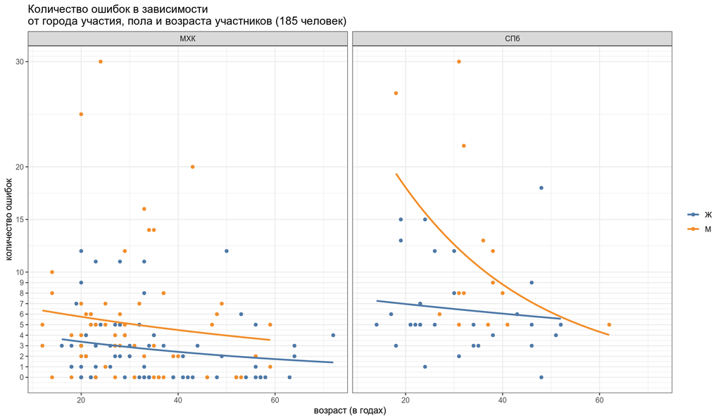

Каждая точка на графике — это один человек (некоторые точки наслаиваются друг на друга). Линия — пуассоновская регрессия, которую можно считать некоторой оценкой связи количества ошибок и возраста участников разного пола в каждом из городов. Как видно из графика, участники из Махачкалы справились значительно лучше, и у них наблюдается отрицательная связь: чем больше возраст, тем меньше ошибок (у женщин в Махачкале ошибок в среднем меньше, чем у мужчин). В Санкт-Петербурге та же картина: чем старше, тем лучше справились, но женщины практически не изменяются с возрастом, мужчины стремительно становятся лучше (хотя данных очень мало, чтобы хоть сколько-то верить в тренд в Санкт-Петербурге). Так же участники из Санкт-Петербурга демонстрируют в среднем результат на уровне слабых результатов из Махачкалы.

Посмотрим теперь те же самые данные, но без переменной возраст (ведь мы теряем так много данных):

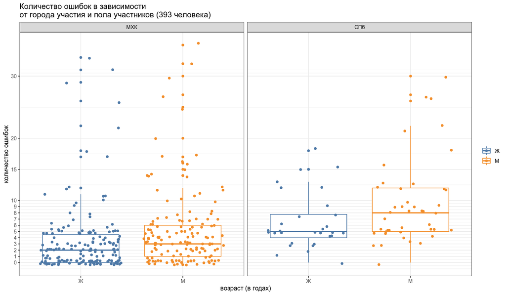

На данном графике видно, что в целом, лучше всего справляются женщины из Махачкалы, которые делают около 2 ошибок, мужчины делают около 3, а в Санкт-Петербурге женшины делают в среднем 5 ошибок, а мужчины 8.